# MSRR CH02, Sections 4-6 HW

SOLUTIONS / Jill E. Thomley

Updated: Wednesday, March 06, 2019 @ 02:03:18 PM

**Instructions**

Complete the following problems from *Mathematical Statistics with Resampling and R*. You can access the textbook datasets on our [Class Data Files](https://stat-jet-asu.github.io/Datasets/DatasetList.html) page or from the `R` package `resampledata`. The textbook examples use base `R`code for plotting, but you `ggplot2` for visualizations. You may use `table()` to make tables, but you should use `dplyr` for other summaries. Refer to the case studies in Chapter 1 to add informative titles and axis labels to your plots and to provide context for your answers.

Load the packages and datasets you need here.

```r
library(dplyr)
library(ggplot2)
library(moments)
library(ggthemes)
library(resampledata)
```

#### Problem 2.7

Part (a)

Note: For summaries, include sample size, mean, standard deviation, five-number summary, skewness, and kurtosis.

```r
Spruce %>%
  summarize(n     = n(),
            xbar  = mean(Ht.change, na.rm = TRUE),
            stdev = sd(Ht.change, na.rm = TRUE),
            min   = fivenum(Ht.change)[1],
            Q1    = fivenum(Ht.change)[2],
            med   = fivenum(Ht.change)[3],
            Q3    = fivenum(Ht.change)[4],
            max   = fivenum(Ht.change)[5],
            skew  = skewness(Ht.change, na.rm = TRUE),
            kurt  = kurtosis(Ht.change, na.rm = TRUE))
```

```
   n     xbar    stdev min   Q1  med    Q3  max       skew     kurt
1 72 30.93333 11.04943 8.3 23.1 30.1 38.35 51.5 0.05742502 2.379064
```

Part (b)

Note: Also make a density plot and ecdf plot. As we learned to do in class, include theoretical normal reference curves.

```r
ht_stats <- Spruce %>%
  summarize(xbar = mean(Ht.change), s = sd(Ht.change))
ht_stats
```

```
      xbar        s
1 30.93333 11.04943
```

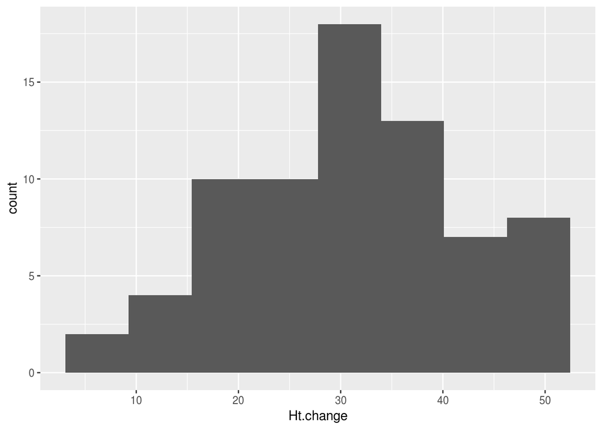

```r
ggplot(Spruce, aes(x = Ht.change)) +
  geom_histogram(bins = sqrt(72))
```

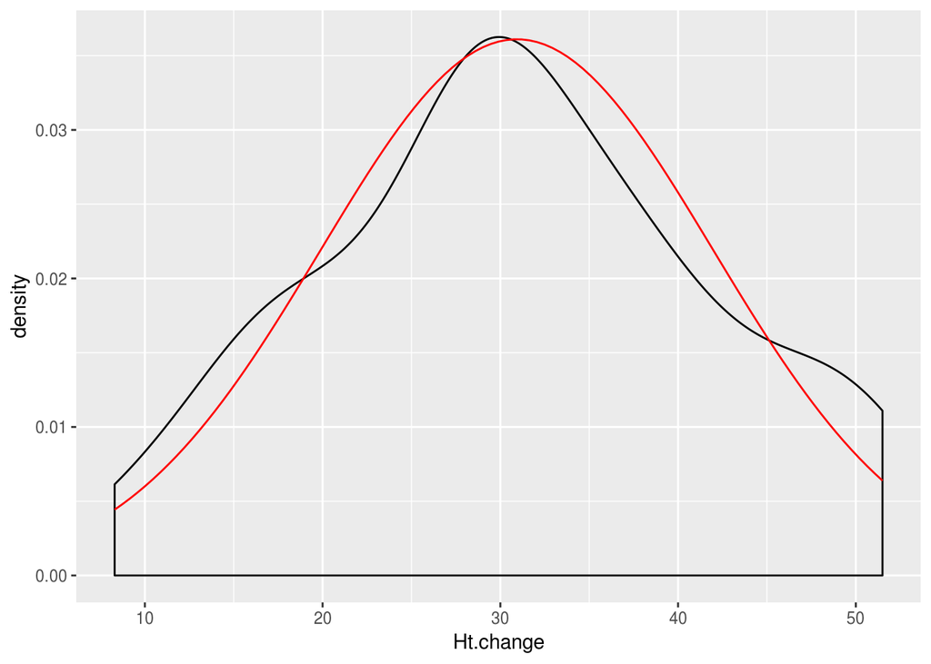

```r
ggplot(Spruce, aes(x = Ht.change)) +
  geom_density() +
  stat_function(fun = dnorm,
                args = list(ht_stats$xbar, ht_stats$s),
                color = "red")
```

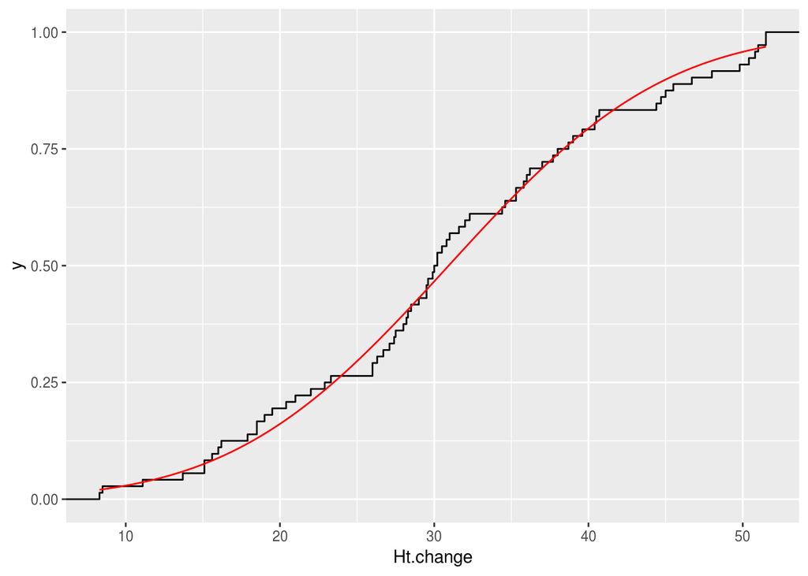

```r
ggplot(Spruce, aes(x = Ht.change)) +
  stat_ecdf() +
  stat_function(fun = pnorm,
                args = list(ht_stats$xbar, ht_stats$s),
                color = "red")
```

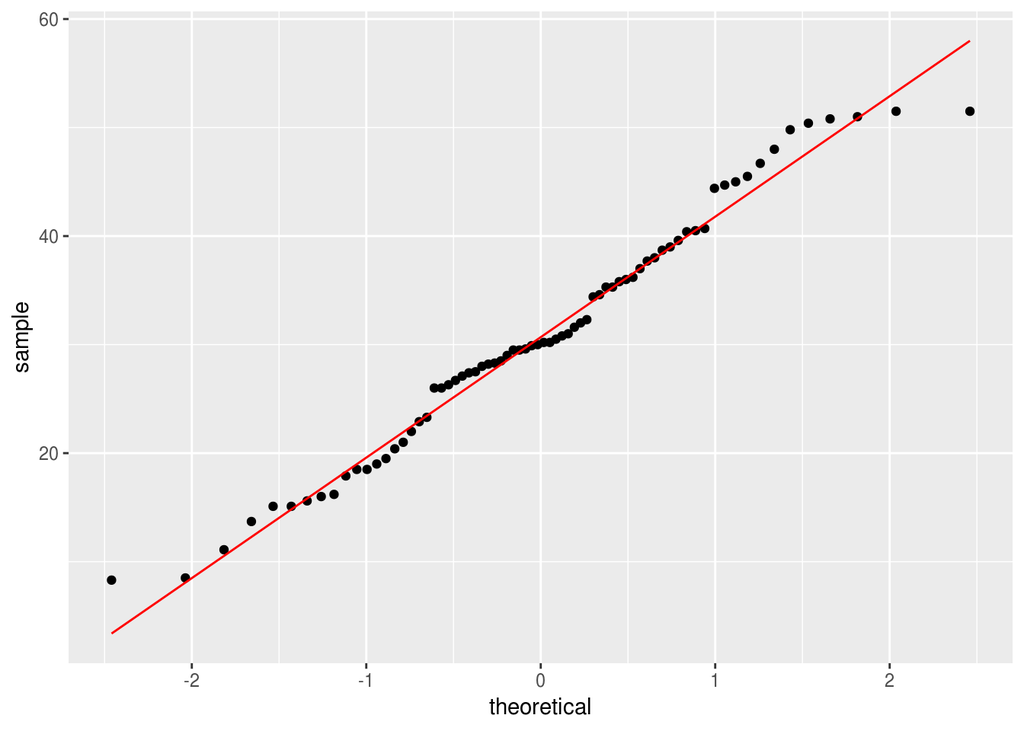

```r
ggplot(Spruce, aes(sample = Ht.change)) +
  stat_qq() +
  stat_qq_line(color = "red")
```

ANSWER: The plots based on data do not deviate too far from the theoretical normal plots. There is no evidence of strong skew or outliers. The distribution appears to be approximately normal.

Part (c)

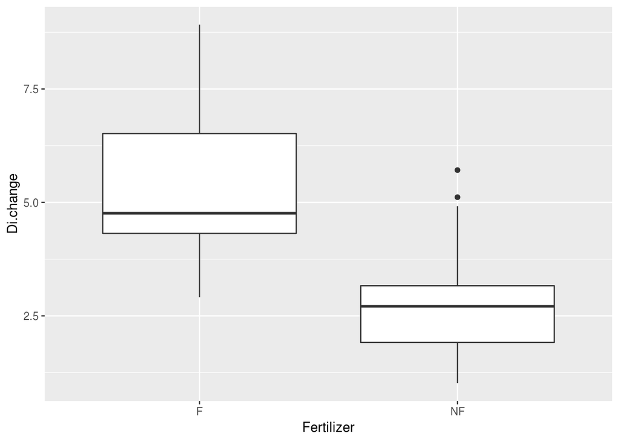

```r
ggplot(Spruce, aes(x = Fertilizer, y = Di.change)) +
  geom_boxplot()
```

Part (d)

Note: For summaries, include sample size, mean, standard deviation, five-number summary, skewness, and kurtosis. Use `dplyr` functions rather than `tapply()`.

```r
Spruce %>%
  group_by(Fertilizer) %>%
  summarize(n     = n(),
            xbar  = mean(Di.change, na.rm = TRUE),
            stdev = sd(Di.change, na.rm = TRUE),
            min   = fivenum(Di.change)[1],
            Q1    = fivenum(Di.change)[2],
            med   = fivenum(Di.change)[3],
            Q3    = fivenum(Di.change)[4],
            max   = fivenum(Di.change)[5],
            skew  = skewness(Di.change, na.rm = TRUE),
            kurt  = kurtosis(Di.change, na.rm = TRUE))
```

```
# A tibble: 2 x 11
  Fertilizer     n  xbar stdev   min    Q1   med    Q3   max  skew  kurt
  <fct>      <int> <dbl> <dbl> <dbl> <dbl> <dbl> <dbl> <dbl> <dbl> <dbl>
1 F             36  5.27  1.38  2.91  4.32  4.76  6.52  8.92 0.605  2.76
2 NF            36  2.72  1.10  1.02  1.91  2.71  3.21  5.71 0.883  3.53
```

Part (e)

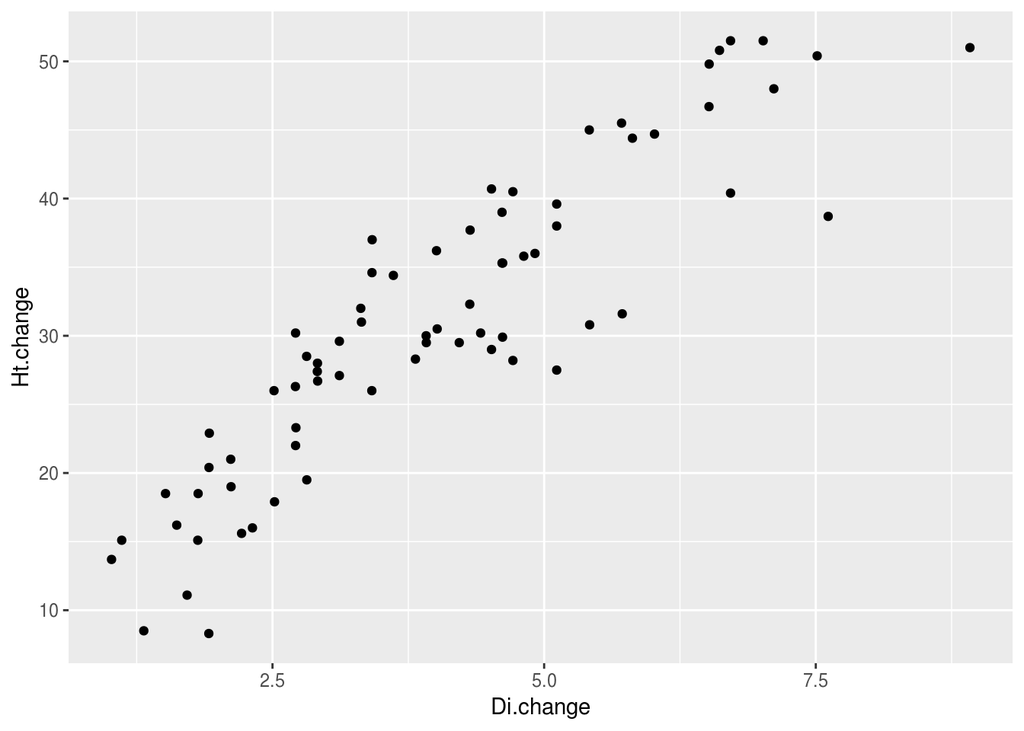

```r
ggplot(Spruce, aes(x = Di.change, y = Ht.change)) +
  geom_point()
```

ANSWER: Change in diameter and change in height appear to have a positive and roughly linear relationship.

#### Problem 2.8

Note: Where the problem asks you to “describe the distribution,” discuss the shape and possible outliers. Choose an appropriate number of bins for the histograms.

Part (a)

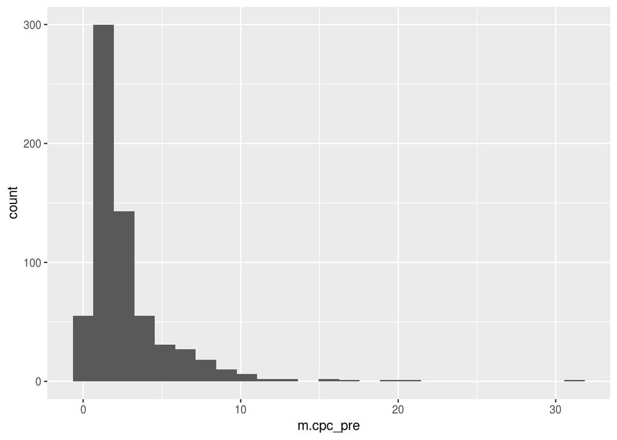

```r
ggplot(MobileAds, aes(x = m.cpc_pre)) +
  geom_histogram(bins = sqrt(655))
```

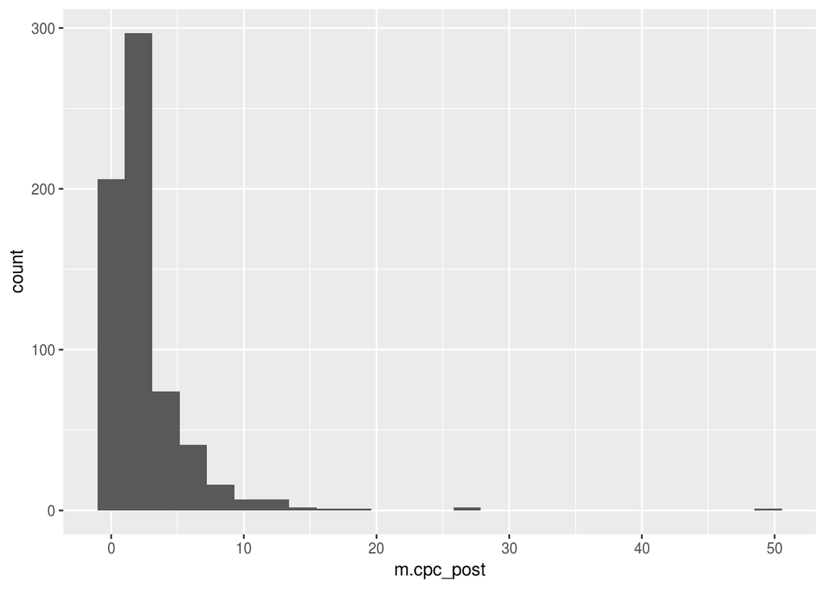

```r
ggplot(MobileAds, aes(x = m.cpc_post)) +
  geom_histogram(bins = sqrt(655))
```

ANSWER: Both distributions appear to be strongly right skewed and may have outliers on the right side.

Part (b)

Note: Use `mutate` and name the new variable `m.cpc_diff`.

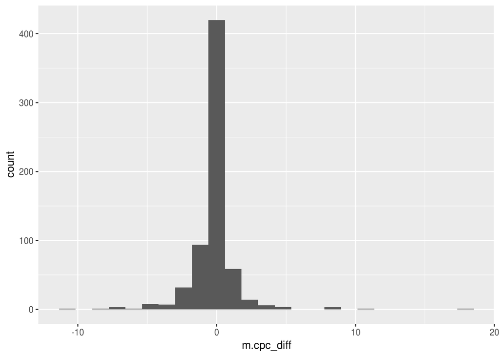

```r
MobileAds <- MobileAds %>%
  mutate(m.cpc_diff = m.cpc_post - m.cpc_pre)

ggplot(MobileAds, aes(x = m.cpc_diff)) +
  geom_histogram(bins = sqrt(655))
```

ANSWER: The difference distribution appears to be roughly symmetric, but it may have outliers on both sides.

Part (c)

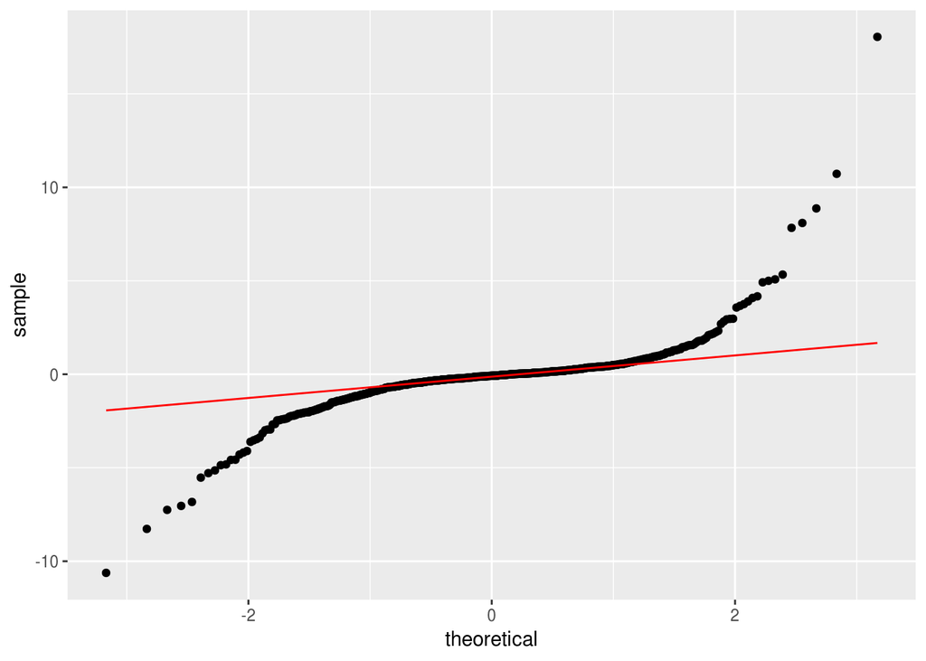

```r
ggplot(MobileAds, aes(sample = m.cpc_diff)) +
  stat_qq() +
  stat_qq_line(color = "red")
```

ANSWER: The distribution does not appear to be approximately normal. It deviates strongly from the theoretical normal reference line. (This shape is characteristic of a *leptokurtic* distribution, which matches what we see in the histogram.)

#### `R` Problem 1

Let the random variable X have a standard normal distribution.

Part (a) : What is P(X < 1.5)?

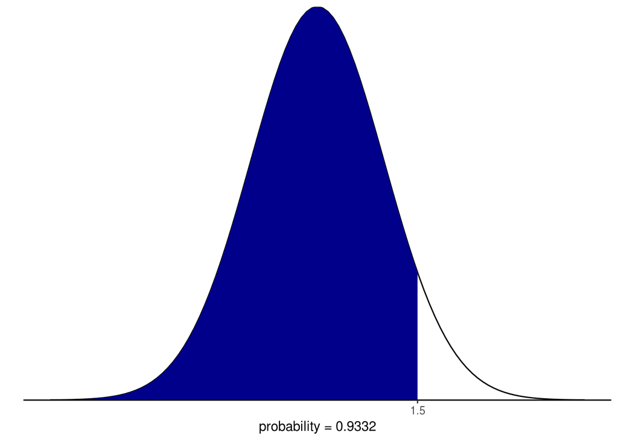

```r
x <- 1.5

prob <- pnorm(x, 0, 1)

ggplot(NULL, aes(c(-4, 4))) +
  stat_function(fun = dnorm, args = list(0, 1)) +
  geom_area(stat = "function", fun = dnorm, fill = "#00008B", xlim = c(-4, x)) +
  scale_x_continuous(breaks = x) +
  scale_y_continuous(breaks = NULL, expand = c(0, 0)) +
  labs(x = sprintf("probability = %1.4f", prob),  y = "") +
  theme_classic()
```

Part (b) : What is P(-2.0 < X < 1.5)?

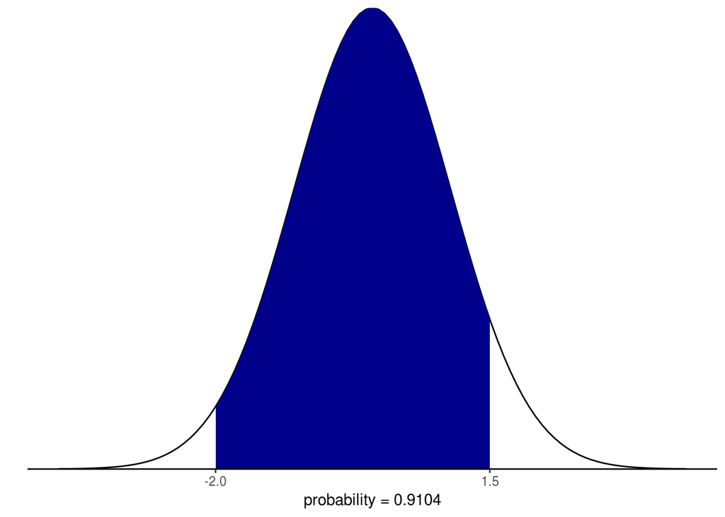

```r
x1 <- -2.0
x2 <- 1.5

prob <- pnorm(x2, 0, 1) - pnorm(x1, 0, 1)

ggplot(NULL, aes(c(-4, 4))) +
  stat_function(fun = dnorm, args = list(0, 1)) +
  geom_area(stat = "function", fun = dnorm, fill = "#00008B", xlim = c(x1, x2)) +
  scale_x_continuous(breaks = c(x1, x2)) +
  scale_y_continuous(breaks = NULL, expand = c(0, 0)) +
  labs(x = sprintf("probability = %1.4f", prob),  y = "") +
  theme_classic()
```

Part (c) : What is P(X < -1.75 or X > 1.75)?

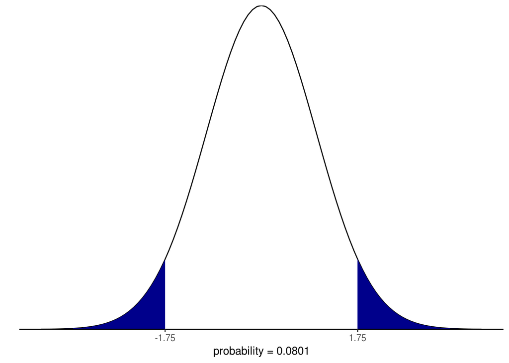

```r
x1 <- -1.75
x2 <- 1.75

prob <- pnorm(x1, 0, 1) + pnorm(x2, 0, 1, lower.tail = FALSE)

ggplot(NULL, aes(c(-4, 4))) +
  stat_function(fun = dnorm, args = list(0, 1)) +
  geom_area(stat = "function", fun = dnorm, fill = "#00008B", xlim = c(-4, x1)) +
  geom_area(stat = "function", fun = dnorm, fill = "#00008B", xlim = c(x2, 4)) +
  scale_x_continuous(breaks = c(x1, x2)) +
  scale_y_continuous(breaks = NULL, expand = c(0, 0)) +
  labs(x = sprintf("probability = %1.4f", prob),  y = "") +
  theme_classic()
```

Part (d) : What value of x satisfies P(X < x) = 0.45?

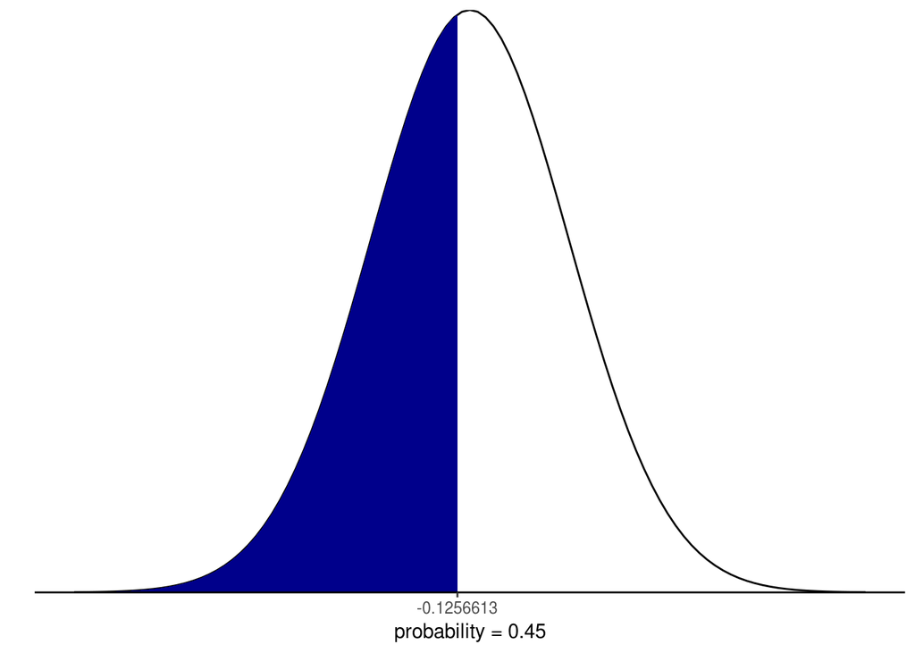

```r
prob <- 0.45

x <- qnorm(prob, 0, 1)

ggplot(NULL, aes(c(-4, 4))) +
  stat_function(fun = dnorm, args = list(0, 1)) +
  geom_area(stat = "function", fun = dnorm, fill = "#00008B", xlim = c(-4, x)) +
  scale_x_continuous(breaks = x) +
  scale_y_continuous(breaks = NULL, expand = c(0, 0)) +
  labs(x = sprintf("probability = %1.2f", prob),  y = "") +
  theme_classic()
```

Part (e) : What value of x satisfies P(X ≥ x) = 0.35?

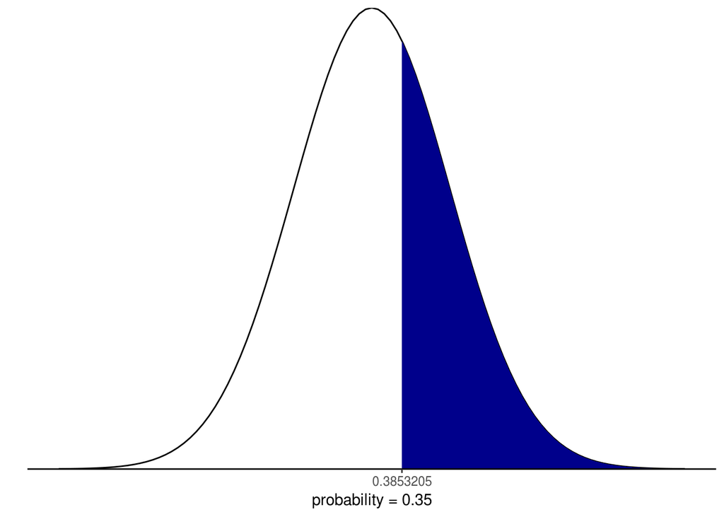

```r
prob <- 0.35

x <- qnorm(prob, 0, 1, lower.tail = FALSE)

ggplot(NULL, aes(c(-4, 4))) +
  stat_function(fun = dnorm, args = list(0, 1)) +
  geom_area(stat = "function", fun = dnorm, fill = "#00008B", xlim = c(x, 4)) +
  scale_x_continuous(breaks = x) +
  scale_y_continuous(breaks = NULL, expand = c(0, 0)) +
  labs(x = sprintf("probability = %1.2f", prob),  y = "") +
  theme_classic()
```

Part (f) : The middle 50% of the area under a standard normal curve lies between what values?

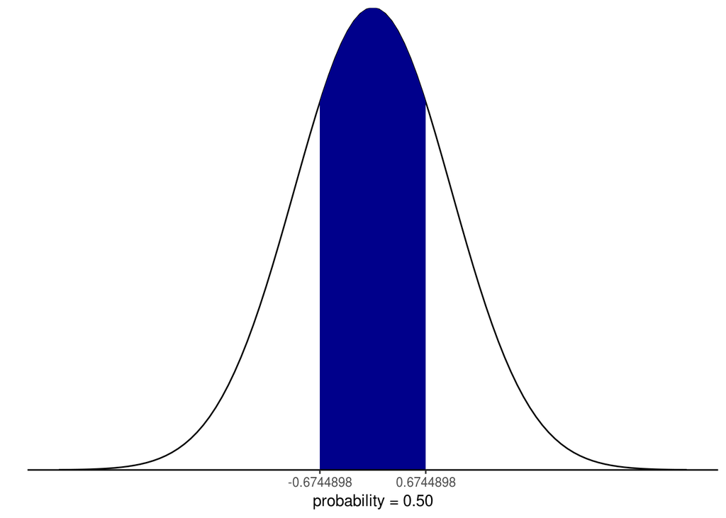

```r
prob1 <- 0.25
prob2 <- 0.25

x1 <- qnorm(prob1, 0, 1)
x2 <- qnorm(prob2, 0, 1, lower.tail = FALSE)

ggplot(NULL, aes(c(-4, 4))) +
  stat_function(fun = dnorm, args = list(0, 1)) +
  geom_area(stat = "function", fun = dnorm, fill = "#00008B", xlim = c(x1, x2)) +
  scale_x_continuous(breaks = c(x1, x2)) +
  scale_y_continuous(breaks = NULL, expand = c(0, 0)) +
  labs(x = sprintf("probability = %1.2f", prob1 + prob2),  y = "") +
  theme_classic()
```

#### `R` Problem 2

In Hottsylvania, the mean July midday temperature is 32 °C with a standard deviation of 3 °C. Assume that midday temperatures can be modeled with an approximately normal distribution. July has 31 days.

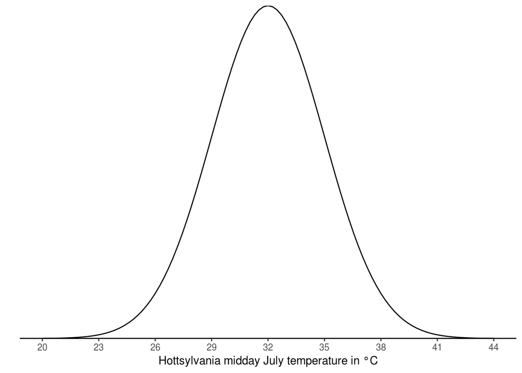

```r
m <- 32   # mean
s <- 3    # standard deviation

ggplot(NULL, aes(c(m - 4*s, m + 4*s))) +
  stat_function(fun = dnorm, args = list(m, s)) +
  scale_x_continuous(breaks = seq(m - 4*s, m + 4*s, s)) +
  scale_y_continuous(breaks = NULL, expand = c(0, 0)) +
  labs(x = "Hottsylvania midday July temperature in °C", y = "") +
  theme_classic()
```

Part (a) : About how many days should be less than 29.44 °C (about 85 °F)?

```r
x    <- 29.44
days <- 31 * pnorm(x, m, s)

sprintf("About %1.0f days should be less than %1.2f °C.", days, x)
```

```
[1] "About 6 days should be less than 29.44 °C."
```

Part (b) : How many days should have a midday temperature between 35 °C and 38 °C?

```r
x1   <- 35
x2   <- 38
days <- 31 * (pnorm(x2, m, s) - pnorm(x1, m, s))

sprintf("About %1.0f days should be between %1.0f °C and %1.0f °C.", days, x1, x2)
```

```
[1] "About 4 days should be between 35 °C and 38 °C."
```

Part (c) : The midday temperature of the hottest 30% of days should be greater than what temperature?

```r
prob <- 0.30
pct  <- prob * 100
x    <- qnorm(prob, m, s, lower.tail = FALSE)

sprintf("The hottest %1.0f%% of days should be greater than %1.2f °C.", pct, x)
```

```
[1] "The hottest 30% of days should be greater than 33.57 °C."
```

#### `R` Problem 3

Generate a random sample of size 100 from a standard normal distribution. Create a density plot and a normal probability plot with appropriate theoretical reference curves.

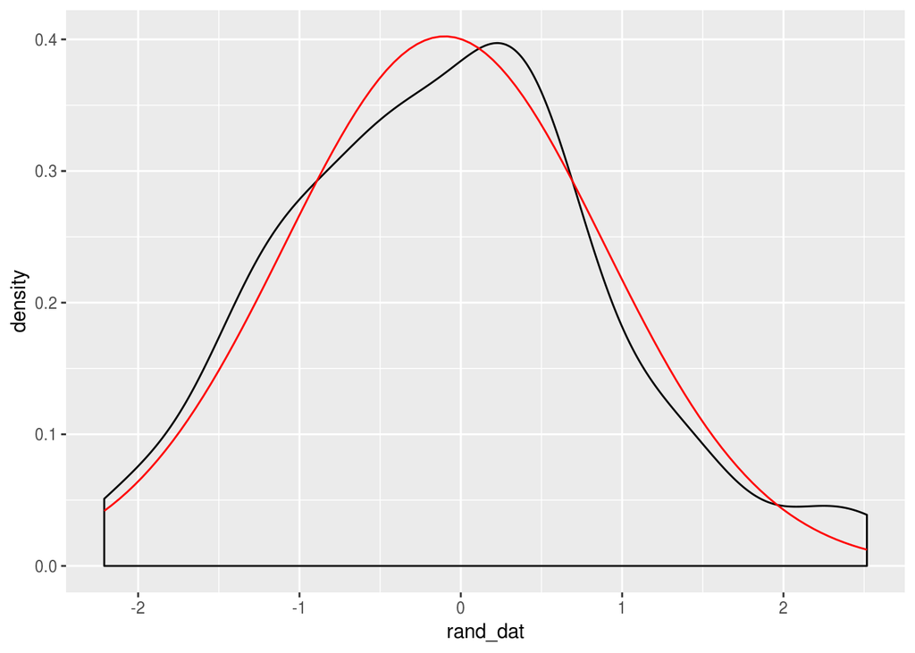

```r
# your plots will vary depending on your random sample
rand_dat <- rnorm(100)

ggplot(NULL, aes(x = rand_dat)) +
  geom_density() +
  stat_function(fun = dnorm,
                args = list(mean(rand_dat), sd(rand_dat)),
                color = "red")
```

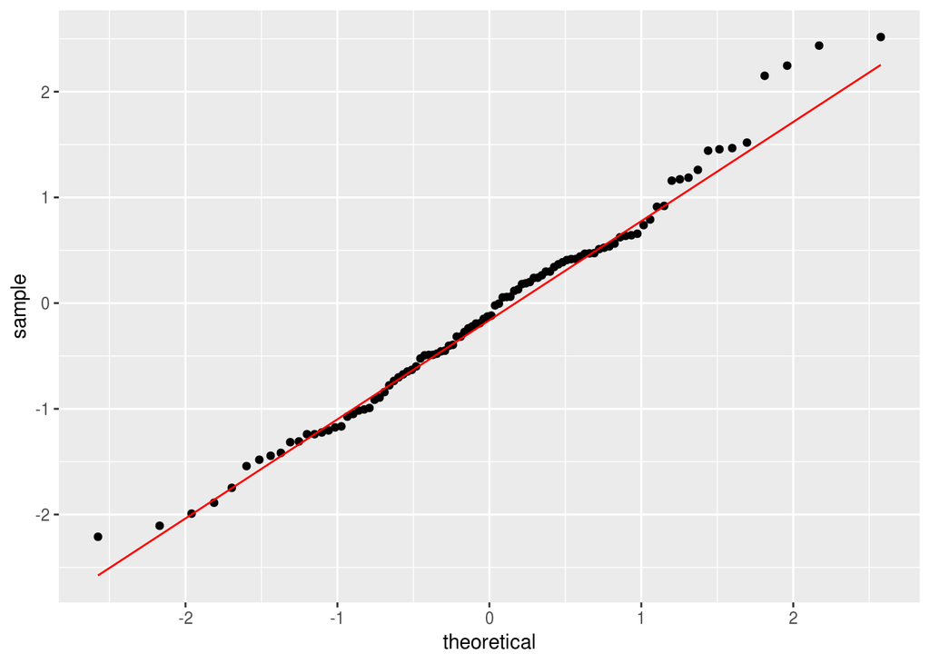

```r
ggplot(NULL, aes(sample = rand_dat)) +
  stat_qq() +
  stat_qq_line(color = "red")
```